# PCA

Hannah Damico

2022-11-28

```r
train <- read.csv("train_recode.csv")
test <- read.csv("test_recode.csv")

data <- rbind(train, test)
```

1. Explore dataset

Show first 5 rows of data

```r
head(data,5)
```

```
##   X subjid ALP_1 ALP_2 ALP_3 ALP_4    ALT_1    ALT_2 ALT_3 ALT_4 AST_1    AST_2
## 1 1 132547    NA   101   101   101 45.00000 47.64706    60    60  47.0 67.29412
## 2 2 132551    47    47    47    47 46.00000 46.00000    46    46  82.0 82.00000
## 3 3 132567    NA    NA    NA    NA       NA       NA    NA    NA    NA       NA
## 4 4 132599   116   112   112   112 13.13333 13.00000    13    13  19.4 20.00000
## 5 5 132601    NA    NA    NA    NA       NA       NA    NA    NA    NA       NA
##   AST_3 AST_4 Age_1 Age_2 Age_3 Age_4 Albumin_1 Albumin_2 Albumin_3 Albumin_4
## 1   162   162    64    64    64    64        NA        NA        NA        NA
## 2    82    82    78    78    78    78       1.9       1.9       1.9       1.9
## 3    NA    NA    71    71    71    71        NA        NA        NA        NA
## 4    20    20    53    53    53    53       2.0       2.0       2.0       2.0
## 5    NA    NA    74    74    74    74        NA        NA        NA        NA
##      BUN_1    BUN_2    BUN_3    BUN_4 Bilirubin_1 Bilirubin_2 Bilirubin_3
## 1 15.00000 17.58824 17.93333 16.68750          NA         0.4         0.4
## 2 73.53333 65.72000 58.09091 58.00000    0.300000         0.3         0.3
```

[output cut: 129 more lines]

Get variable names of dataset

```r
# names(data)
```

Find columns with missing data

```r
# Get number of NAs per variable
na_table  = sapply(data, function(y) sum(length(which(is.na(y)))))

# Filter table to only include variables with NA
na_table = na_table[na_table > 0]
# na_table

# Get columns with missing data
missing_cols = names(na_table)
# missing_cols

# Remove Extra Index Variable X
missing_cols = missing_cols[-1]

# Remove outcome from missing cols
missing_cols = missing_cols[-length(missing_cols)]

# missing_cols
```

```r
# Copy dataset
clean_data = data

# Iterate over missing columns
# for(missing_col in missing_cols) {
#   # Mean imputation for survival group
#   clean_data[[missing_col]][is.na(data[[missing_col]]) & data$outcome == 0] =
#     mean(data[[missing_col]][data$outcome == 0], na.rm = TRUE)
#
#   # Mean imputation for non-survival group
#   clean_data[[missing_col]][is.na(data[[missing_col]]) & data$outcome == 1] =
#     mean(data[[missing_col]][data$outcome == 1], na.rm = TRUE)
# }

clean_data <- data %>%
  group_by(subjid) %>%
  tidyr::fill(missing_cols, .direction = c("updown"))


# Remove row with NA outcome
clean_data = clean_data[!is.na(clean_data$In.hospital_death),]
```

```r
# Get number of NAs per variable
na_table_new  = sapply(clean_data, function(y) sum(length(which(is.na(y)))))

na_table_new
```

```
##                  X             subjid              ALP_1              ALP_2
##                  0                  0               1398               1241
##              ALP_3              ALP_4              ALT_1              ALT_2
##               1144               1072               1393               1235
##              ALT_3              ALT_4              AST_1              AST_2
##               1136               1064               1393               1234
##              AST_3              AST_4              Age_1              Age_2
##               1135               1063                214                 94
##              Age_3              Age_4          Albumin_1          Albumin_2
##                 44                  1               1485               1336
##          Albumin_3          Albumin_4              BUN_1              BUN_2
##               1240               1164                428                111
##              BUN_3              BUN_4        Bilirubin_1        Bilirubin_2
##                 59                 16               1404               1244
##        Bilirubin_3        Bilirubin_4      Cholesterol_1      Cholesterol_2
##               1140               1066               1758               1736
##      Cholesterol_3      Cholesterol_4       Creatinine_1       Creatinine_2
##               1713               1703                427                111
##       Creatinine_3       Creatinine_4          DiasABP_1          DiasABP_2
##                 59                 16                352                226
##          DiasABP_3          DiasABP_4             FiO2_1             FiO2_2
##                171                121                475                369
##             FiO2_3             FiO2_4              GCS_1              GCS_2
##                303                263                237                 97
##              GCS_3              GCS_4           Gender_1           Gender_2
##                 45                  1                214                 94
##           Gender_3           Gender_4          Glucose_1          Glucose_2
##                 44                  1                815                266
##          Glucose_3          Glucose_4             HCO3_1             HCO3_2
##                188                 61                473                135
##             HCO3_3             HCO3_4              HCT_1              HCT_2
##                 79                 26                357                119
##              HCT_3              HCT_4               HR_1               HR_2
##                 64                 18                214                 94
##               HR_3               HR_4          ICUType_1          ICUType_2
##                 44                  1                214                 94
##          ICUType_3          ICUType_4                K_1                K_2
##                 44                  1                766                235
##                K_3                K_4          Lactate_1          Lactate_2
##                148                 48                956                786
```

[output cut: 31 more lines]

```
##               1719               1715               1583               1518
##        TroponinT_3        TroponinT_4            Urine_1            Urine_2
##               1483               1471                234                113
##            Urine_3            Urine_4              WBC_1              WBC_2
##                 61                 19                545                132
##              WBC_3              WBC_4           Weight_1           Weight_2
##                 76                 22                214                 94
##           Weight_3           Weight_4               pH_1               pH_2
##                 44                  1                214                 94
##               pH_3               pH_4   height_cleaned_1   height_cleaned_2
##                 44                  1                214                 94
##   height_cleaned_3   height_cleaned_4 MechVent_cleaned_1 MechVent_cleaned_2
##                 44                  1                214                 94
## MechVent_cleaned_3 MechVent_cleaned_4  In.hospital_death
##                 44                  1                  0
```

Extract only continuous variables

```r
# De-select non-continuous variables
cont_data = clean_data %>%
  select(-contains(c("MechVent", "Gender", "ICUType")), - X)
```

```r
head(cont_data)
```

```
## # A tibble: 6 × 154
## # Groups:   subjid [6]
##   subjid ALP_1 ALP_2 ALP_3 ALP_4 ALT_1 ALT_2 ALT_3 ALT_4 AST_1 AST_2 AST_3 AST_4
##    <int> <dbl> <dbl> <dbl> <dbl> <dbl> <dbl> <dbl> <dbl> <dbl> <dbl> <dbl> <dbl>
## 1 132547    NA   101   101   101  45    47.6    60    60  47    67.3   162   162
## 2 132551    47    47    47    47  46    46      46    46  82    82      82    82
## 3 132567    NA    NA    NA    NA  NA    NA      NA    NA  NA    NA      NA    NA
## 4 132599   116   112   112   112  13.1  13      13    13  19.4  20      20    20
## 5 132601    NA    NA    NA    NA  NA    NA      NA    NA  NA    NA      NA    NA
## 6 132602    NA    NA    NA    NA  NA    NA      NA    NA  NA    NA      NA    NA
## # … with 141 more variables: Age_1 <int>, Age_2 <int>, Age_3 <int>,
## #   Age_4 <int>, Albumin_1 <dbl>, Albumin_2 <dbl>, Albumin_3 <dbl>,
## #   Albumin_4 <dbl>, BUN_1 <dbl>, BUN_2 <dbl>, BUN_3 <dbl>, BUN_4 <dbl>,
## #   Bilirubin_1 <dbl>, Bilirubin_2 <dbl>, Bilirubin_3 <dbl>, Bilirubin_4 <dbl>,
## #   Cholesterol_1 <int>, Cholesterol_2 <dbl>, Cholesterol_3 <int>,
## #   Cholesterol_4 <dbl>, Creatinine_1 <dbl>, Creatinine_2 <dbl>,
## #   Creatinine_3 <dbl>, Creatinine_4 <dbl>, DiasABP_1 <dbl>, DiasABP_2 <dbl>, …
```

Show summary of data

```r
summary(cont_data)
```

```
##      subjid           ALP_1             ALP_2             ALP_3
##  Min.   :132540   Min.   :  12.00   Min.   :  12.00   Min.   :  12.00
##  1st Qu.:135165   1st Qu.:  52.00   1st Qu.:  52.00   1st Qu.:  52.00
##  Median :137710   Median :  77.00   Median :  74.00   Median :  72.00
##  Mean   :137662   Mean   :  97.05   Mean   :  93.59   Mean   :  90.75
##  3rd Qu.:140158   3rd Qu.: 105.00   3rd Qu.: 101.00   3rd Qu.:  98.00
##  Max.   :142673   Max.   :1504.00   Max.   :1384.83   Max.   :1339.00
##                   NA's   :1398      NA's   :1241      NA's   :1144
##      ALP_4             ALT_1             ALT_2             ALT_3
##  Min.   :  12.00   Min.   :   1.00   Min.   :   1.00   Min.   :   1.0
##  1st Qu.:  52.00   1st Qu.:  19.00   1st Qu.:  18.45   1st Qu.:  18.0
##  Median :  71.00   Median :  38.50   Median :  35.00   Median :  34.0
##  Mean   :  88.48   Mean   : 174.75   Mean   : 167.44   Mean   : 184.3
##  3rd Qu.:  96.78   3rd Qu.:  92.71   3rd Qu.:  82.64   3rd Qu.:  82.0
##  Max.   :1457.80   Max.   :6177.00   Max.   :7068.38   Max.   :9123.2
##  NA's   :1072      NA's   :1393      NA's   :1235      NA's   :1136
##      ALT_4             AST_1             AST_2             AST_3
##  Min.   :   3.00   Min.   :    7.0   Min.   :    7.0   Min.   :    7.0
##  1st Qu.:  18.00   1st Qu.:   29.0   1st Qu.:   29.0   1st Qu.:   28.0
##  Median :  33.13   Median :   57.0   Median :   57.0   Median :   57.0
##  Mean   : 188.75   Mean   :  272.8   Mean   :  267.5   Mean   :  292.6
##  3rd Qu.:  80.00   3rd Qu.:  183.9   3rd Qu.:  153.0   3rd Qu.:  148.0
##  Max.   :9894.00   Max.   :11920.0   Max.   :11657.5   Max.   :11874.6
##  NA's   :1064      NA's   :1393      NA's   :1234      NA's   :1135
##      AST_4              Age_1           Age_2           Age_3
##  Min.   :    7.00   Min.   :17.00   Min.   :17.00   Min.   :17.00
##  1st Qu.:   27.35   1st Qu.:56.00   1st Qu.:56.00   1st Qu.:56.00
##  Median :   53.00   Median :68.00   Median :68.00   Median :68.00
##  Mean   :  295.29   Mean   :65.64   Mean   :65.47   Mean   :65.45
##  3rd Qu.:  134.43   3rd Qu.:78.00   3rd Qu.:78.00   3rd Qu.:78.00
##  Max.   :15680.00   Max.   :90.00   Max.   :90.00   Max.   :90.00
##  NA's   :1063       NA's   :214     NA's   :94      NA's   :44
##      Age_4         Albumin_1       Albumin_2       Albumin_3
##  Min.   :17.00   Min.   :1.100   Min.   :1.100   Min.   :1.100
##  1st Qu.:56.00   1st Qu.:2.471   1st Qu.:2.500   1st Qu.:2.457
##  Median :68.00   Median :2.960   Median :2.900   Median :2.900
##  Mean   :65.39   Mean   :2.931   Mean   :2.921   Mean   :2.893
##  3rd Qu.:78.00   3rd Qu.:3.400   3rd Qu.:3.400   3rd Qu.:3.337
##  Max.   :90.00   Max.   :5.000   Max.   :4.667   Max.   :4.600
##  NA's   :1       NA's   :1485    NA's   :1336    NA's   :1240
```

[output cut: 257 more lines]

```
##  Min.   :7.138   Min.   :121.9    Min.   :121.9    Min.   :121.9
##  1st Qu.:7.370   1st Qu.:162.6    1st Qu.:162.6    1st Qu.:162.6
##  Median :7.403   Median :170.2    Median :170.2    Median :170.2
##  Mean   :7.399   Mean   :169.7    Mean   :169.8    Mean   :169.8
##  3rd Qu.:7.434   3rd Qu.:177.8    3rd Qu.:177.8    3rd Qu.:177.8
##  Max.   :7.579   Max.   :205.7    Max.   :205.7    Max.   :205.7
##  NA's   :1       NA's   :214      NA's   :94       NA's   :44
##  height_cleaned_4 In.hospital_death
##  Min.   :121.9    Min.   :0.0000
##  1st Qu.:162.6    1st Qu.:0.0000
##  Median :170.2    Median :0.0000
##  Mean   :169.9    Mean   :0.1295
##  3rd Qu.:177.8    3rd Qu.:0.0000
##  Max.   :205.7    Max.   :1.0000
##  NA's   :1
```

Get dimensions of data

```r
nrow(cont_data)
```

```
## [1] 1815
```

```r
ncol(cont_data)
```

```
## [1] 154
```

There are 1815 observations and 154 continuous variables.

2. It is important to standardize the variables to have mean zero and standard deviation one before performing PCA.

Calculate PCs

```r
cont_data <- cont_data %>%  mutate_all(~replace(., is.na(.), -1))
pr.out=prcomp(cont_data, scale=TRUE)
```

prcomp() function centers the variables to have mean zero. By using the option scale=TRUE, we scale the variables to have standard deviation one.

Print output categories of pc object

```r
names(pr.out)
```

```
## [1] "sdev"     "rotation" "center"   "scale"    "x"
```

Print variable means

```r
pr.out$center
```

```
##            subjid             ALP_1             ALP_2             ALP_3
##      1.376625e+05      2.152671e+01      2.891518e+01      3.292086e+01
##             ALP_4             ALT_1             ALT_2             ALT_3
##      3.562880e+01      3.986360e+01      5.282686e+01      6.832510e+01
##             ALT_4             AST_1             AST_2             AST_3
##      7.751510e+01      6.266135e+01      8.494605e+01      1.090132e+02
##             AST_4             Age_1             Age_2             Age_3
##      1.217591e+02      5.778182e+01      6.202975e+01      6.383967e+01
##             Age_4         Albumin_1         Albumin_2         Albumin_3
##      6.535372e+01     -2.853433e-01      3.480413e-02      2.331509e-01
##         Albumin_4             BUN_1             BUN_2             BUN_3
##      3.909395e-01      1.826314e+01      2.240841e+01      2.342090e+01
##             BUN_4       Bilirubin_1       Bilirubin_2       Bilirubin_3
##      2.471469e+01     -2.749178e-01     -6.838778e-02      6.772933e-02
##       Bilirubin_4     Cholesterol_1     Cholesterol_2     Cholesterol_3
##      1.638496e-01      4.037466e+00      5.951751e+00      7.920661e+00
##     Cholesterol_4      Creatinine_1      Creatinine_2      Creatinine_3
##      8.775084e+00      7.802917e-01      1.204377e+00      1.302327e+00
##      Creatinine_4         DiasABP_1         DiasABP_2         DiasABP_3
##      1.384781e+00      4.692426e+01      5.027773e+01      5.203549e+01
##         DiasABP_4            FiO2_1            FiO2_2            FiO2_3
##      5.422910e+01      1.820906e-01      2.027078e-01      2.581311e-01
##            FiO2_4             GCS_1             GCS_2             GCS_3
##      2.886395e-01      7.185220e+00      9.993198e+00      1.123536e+01
##             GCS_4         Glucose_1         Glucose_2         Glucose_3
##      1.185879e+01      8.480127e+01      1.165327e+02      1.170149e+02
##         Glucose_4            HCO3_1            HCO3_2            HCO3_3
##      1.244064e+02      1.646227e+01      2.121518e+01      2.216999e+01
##            HCO3_4             HCT_1             HCT_2             HCT_3
##      2.342179e+01      2.506803e+01      2.919581e+01      2.976855e+01
##             HCT_4              HR_1              HR_2              HR_3
##      2.987300e+01      7.756110e+01      8.295527e+01      8.567460e+01
##              HR_4               K_1               K_2               K_3
##      8.743741e+01      2.000627e+00      3.600602e+00      3.833383e+00
##               K_4         Lactate_1         Lactate_2         Lactate_3
##      4.064539e+00      8.121797e-01      9.320058e-01      9.164295e-01
##         Lactate_4             MAP_1             MAP_2             MAP_3
##      9.412747e-01      6.271865e+01      6.757741e+01      7.063909e+01
##             MAP_4              Mg_1              Mg_2              Mg_3
##      7.382418e+01      1.007763e+00      1.720832e+00      1.876500e+00
```

[output cut: 23 more lines]

```
##      3.713223e+01     -6.582750e-01     -5.255165e-01     -5.020996e-01
##       TroponinI_4       TroponinT_1       TroponinT_2       TroponinT_3
##     -5.164105e-01     -6.831992e-01     -6.044286e-01     -5.670775e-01
##       TroponinT_4           Urine_1           Urine_2           Urine_3
##     -5.523536e-01      1.399693e+02      8.970395e+01      9.955068e+01
##           Urine_4             WBC_1             WBC_2             WBC_3
##      1.097670e+02      9.408372e+00      1.229875e+01      1.253983e+01
##             WBC_4          Weight_1          Weight_2          Weight_3
##      1.278943e+01      7.284097e+01      7.957372e+01      8.341830e+01
##          Weight_4              pH_1              pH_2              pH_3
##      8.583241e+01      6.379887e+00      6.951479e+00      7.190188e+00
##              pH_4  height_cleaned_1  height_cleaned_2  height_cleaned_3
##      7.394485e+00      1.496094e+02      1.609610e+02      1.656858e+02
##  height_cleaned_4 In.hospital_death
##      1.697609e+02      1.294766e-01
```

```r
pr.out$scale^2
```

```
##            subjid             ALP_1             ALP_2             ALP_3
##      8.448517e+06      4.217810e+03      4.878749e+03      5.131997e+03
##             ALP_4             ALT_1             ALT_2             ALT_3
##      4.932055e+03      6.657739e+04      1.045100e+05      1.683910e+05
##             ALT_4             AST_1             AST_2             AST_3
##      2.009111e+05      1.740651e+05      2.800393e+05      4.292987e+05
##             AST_4             Age_1             Age_2             Age_3
##      5.664252e+05      6.757330e+02      4.490366e+02      3.432527e+02
##             Age_4         Albumin_1         Albumin_2         Albumin_3
##      2.481670e+02      2.378442e+00      3.096071e+00      3.407274e+00
##         Albumin_4             BUN_1             BUN_2             BUN_3
##      3.612409e+00      4.028158e+02      3.746553e+02      3.788846e+02
##             BUN_4       Bilirubin_1       Bilirubin_2       Bilirubin_3
##      3.617681e+02      7.042092e+00      8.267048e+00      8.741313e+00
##       Bilirubin_4     Cholesterol_1     Cholesterol_2     Cholesterol_3
##      9.510662e+00      8.440548e+02      1.144455e+03      1.440888e+03
##     Cholesterol_4      Creatinine_1      Creatinine_2      Creatinine_3
##      1.568513e+03      2.532837e+00      2.180939e+00      2.167181e+00
##      Creatinine_4         DiasABP_1         DiasABP_2         DiasABP_3
##      2.068727e+00      6.341415e+02      4.632555e+02      4.052665e+02
##         DiasABP_4            FiO2_1            FiO2_2            FiO2_3
##      3.482463e+02      5.121110e-01      3.835316e-01      3.334063e-01
##            FiO2_4             GCS_1             GCS_2             GCS_3
##      2.986006e-01      2.232420e+01      2.112045e+01      1.770361e+01
##             GCS_4         Glucose_1         Glucose_2         Glucose_3
##      1.422781e+01      8.126994e+03      4.347266e+03      3.071297e+03
##         Glucose_4            HCO3_1            HCO3_2            HCO3_3
##      1.810187e+03      1.208219e+02      5.444302e+01      3.944553e+01
##            HCO3_4             HCT_1             HCT_2             HCT_3
##      2.370746e+01      1.865382e+02      8.210466e+01      5.065887e+01
##             HCT_4              HR_1              HR_2              HR_3
##      2.599723e+01      1.035137e+03      5.982577e+02      4.029870e+02
##              HR_4               K_1               K_2               K_3
##      2.209680e+02      6.820809e+00      3.447723e+00      2.359945e+00
##               K_4         Lactate_1         Lactate_2         Lactate_3
##      9.487857e-01      5.395593e+00      4.334309e+00      3.764839e+00
##         Lactate_4             MAP_1             MAP_2             MAP_3
##      3.591633e+00      1.099612e+03      8.049662e+02      7.184653e+02
##             MAP_4              Mg_1              Mg_2              Mg_3
##      6.038267e+02      2.259619e+00      1.108510e+00      7.325462e-01
```

[output cut: 23 more lines]

```
##      1.187405e+00      7.994607e+00      9.987372e+00      1.076992e+01
##       TroponinI_4       TroponinT_1       TroponinT_2       TroponinT_3
##      1.029458e+01      2.267349e+00      2.340798e+00      2.405379e+00
##       TroponinT_4           Urine_1           Urine_2           Urine_3
##      2.413434e+00      2.060627e+04      1.822404e+04      1.556072e+04
##           Urine_4             WBC_1             WBC_2             WBC_3
##      1.459534e+04      9.079323e+01      5.791139e+01      4.967006e+01
##             WBC_4          Weight_1          Weight_2          Weight_3
##      3.968204e+01      1.218471e+03      8.691929e+02      7.097228e+02
##          Weight_4              pH_1              pH_2              pH_3
##      5.361220e+02      7.287086e+00      3.458046e+00      1.670274e+00
##              pH_4  height_cleaned_1  height_cleaned_2  height_cleaned_3
##      4.184545e-02      3.138802e+03      1.547866e+03      8.077010e+02
##  height_cleaned_4 In.hospital_death
##      1.358632e+02      1.127745e-01
```

3. The rotation matrix provides the principal component loadings; each col- umn of pr.out$rotation contains the corresponding principal component loading vector.

```r
pr.out$rotation[,1:2]
```

```
##                             PC1           PC2
## subjid             0.0055620214 -0.0035541275
## ALP_1              0.0404035610  0.1268788088
## ALP_2              0.0320314450  0.1356835290
## ALP_3              0.0219114781  0.1405989498
## ALP_4              0.0068113709  0.1428284750
## ALT_1              0.0249346837  0.0612588808
## ALT_2              0.0204113918  0.0665085848
## ALT_3              0.0163320337  0.0636511025
## ALT_4              0.0110607478  0.0591931281
## AST_1              0.0245873555  0.0558499280
## AST_2              0.0224926398  0.0616391756
## AST_3              0.0188186263  0.0628319928
## AST_4              0.0130642381  0.0518335638
## Age_1              0.1299795156 -0.0570489960
## Age_2              0.1160425965 -0.0447336220
## Age_3              0.0734640316 -0.0274980625
## Age_4              0.0017491166 -0.0266828728
## Albumin_1          0.0506427795  0.1231493318
## Albumin_2          0.0397767721  0.1352427778
## Albumin_3          0.0216789550  0.1460440901
## Albumin_4         -0.0006791715  0.1475199326
## BUN_1              0.0840990015  0.1202568658
## BUN_2              0.0680433553  0.1293991709
## BUN_3              0.0422907827  0.1410844459
## BUN_4              0.0203065844  0.1351895129
## Bilirubin_1        0.0325777774  0.1079125724
## Bilirubin_2        0.0262225010  0.1152472110
## Bilirubin_3        0.0191992651  0.1206046532
## Bilirubin_4        0.0108494198  0.1185669540
## Cholesterol_1      0.0178703990  0.0275296405
## Cholesterol_2      0.0112818142  0.0341422073
## Cholesterol_3     -0.0057982209  0.0428350082
## Cholesterol_4     -0.0196982771  0.0446263525
## Creatinine_1       0.0941119043  0.1018596460
## Creatinine_2       0.0777869249  0.1020255036
## Creatinine_3       0.0516702710  0.1142560709
## Creatinine_4       0.0213312215  0.1132040832
## DiasABP_1          0.1259287640 -0.1198403030
## DiasABP_2          0.1222104345 -0.1022357059
```

[output cut: 100 more lines]

```
## WBC_3              0.0748467012  0.0399311609
## WBC_4              0.0384866335  0.0386606643
## Weight_1           0.1367153028 -0.0372972928
## Weight_2           0.1228203172 -0.0241245668
## Weight_3           0.0863457933 -0.0168141813
## Weight_4           0.0251514210 -0.0136002560
## pH_1               0.1611956478 -0.0542625526
## pH_2               0.1697089079 -0.0377971055
## pH_3               0.1368142074 -0.0130658619
## pH_4               0.0047192203 -0.0192367475
## height_cleaned_1   0.1611391342 -0.0516999232
## height_cleaned_2   0.1670238936 -0.0333143642
## height_cleaned_3   0.1312487526 -0.0071269090
## height_cleaned_4   0.0106655706  0.0066145455
## In.hospital_death  0.0068303267  0.0873390399
```

```r
ncol(pr.out$rotation)
```

```
## [1] 154
```

```r
dim(pr.out$x)
```

```
## [1] 1815  154
```

```r
pr.out$x[1:20,1:2]
```

```
##               PC1        PC2
##  [1,]   3.9028518  0.8332246
##  [2,]   1.9830894  2.9520771
##  [3,]  -0.5609016 -2.9807262
##  [4,]   1.9779442  2.1549628
##  [5,]   1.2221876 -4.0897220
##  [6,] -22.2646756  2.1927630
##  [7,]  -0.9783594  5.4099324
##  [8,]  -0.3838836 -3.7278359
##  [9,]  -2.5692281 -4.4971818
## [10,]  -0.1227090 -5.4104333
## [11,]  -1.1394386 -4.1499001
## [12,]   0.6919928 -3.1993041
## [13,]  -1.3194450 11.3744348
## [14,]  -0.6407372 -3.7612104
## [15,]   0.2226709  2.6860470
## [16,]   1.2900877 -4.0203185
## [17,]   3.0885176  2.2610249
## [18,]   1.4449009  0.6022298
## [19,]   2.8090938  0.5632495
## [20,]   3.5556505  4.4024432
```

I only printed out the first 20 observations for the first two components for simplicity sake.

4. Plot the first 2 principal components.

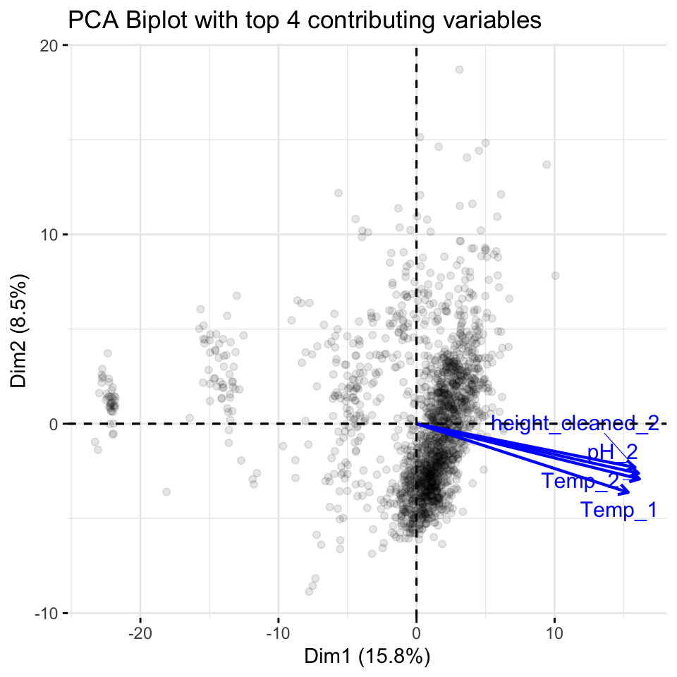

```r
fviz_pca_biplot(pr.out, repel = TRUE, label = "var", select.var = list(contrib = 4), arrowsize = 0.75, alpha.ind = 0.1, col.var = "blue",title = "PCA Biplot with top 4 contributing variables")
```

5. The prcomp() function also outputs the standard deviation of each principal component. For instance, on the data set, we can access these standard deviations as follows:

```r
pr.var=pr.out$sdev^2
pr.var
```

```
##   [1] 2.439147e+01 1.301740e+01 9.313830e+00 6.751461e+00 6.249737e+00
##   [6] 5.334657e+00 5.045252e+00 4.778142e+00 4.167298e+00 3.937629e+00
##  [11] 3.612118e+00 3.523844e+00 3.413706e+00 3.301231e+00 2.971657e+00
##  [16] 2.774691e+00 2.470792e+00 2.410586e+00 2.253665e+00 2.158711e+00
##  [21] 2.038040e+00 1.988816e+00 1.869881e+00 1.730310e+00 1.682831e+00
##  [26] 1.621211e+00 1.585177e+00 1.447410e+00 1.367028e+00 1.210274e+00
##  [31] 1.081592e+00 1.039694e+00 1.004678e+00 9.838182e-01 9.430545e-01
##  [36] 8.831317e-01 7.874328e-01 7.407603e-01 7.327809e-01 7.305042e-01
##  [41] 6.661739e-01 6.278204e-01 5.833180e-01 5.645935e-01 5.236725e-01
##  [46] 5.047588e-01 4.797957e-01 4.667551e-01 4.530034e-01 4.334009e-01
##  [51] 4.188943e-01 4.096426e-01 3.940712e-01 3.705994e-01 3.559850e-01
##  [56] 3.442690e-01 3.338992e-01 3.254790e-01 3.137061e-01 3.103129e-01
##  [61] 2.868880e-01 2.850610e-01 2.809383e-01 2.735261e-01 2.674566e-01
##  [66] 2.541599e-01 2.425678e-01 2.308624e-01 2.276801e-01 2.182188e-01
##  [71] 2.010611e-01 2.002042e-01 1.910840e-01 1.798072e-01 1.742123e-01
```

[output cut: 16 more lines]

Proportion of variance explained.

```r
pve=pr.var/sum(pr.var)
```

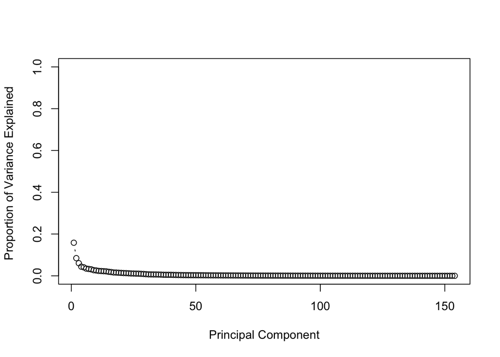

```r
plot(pve, xlab="Principal Component", ylab="Proportion of Variance Explained ", ylim=c(0,1),type='b')
```

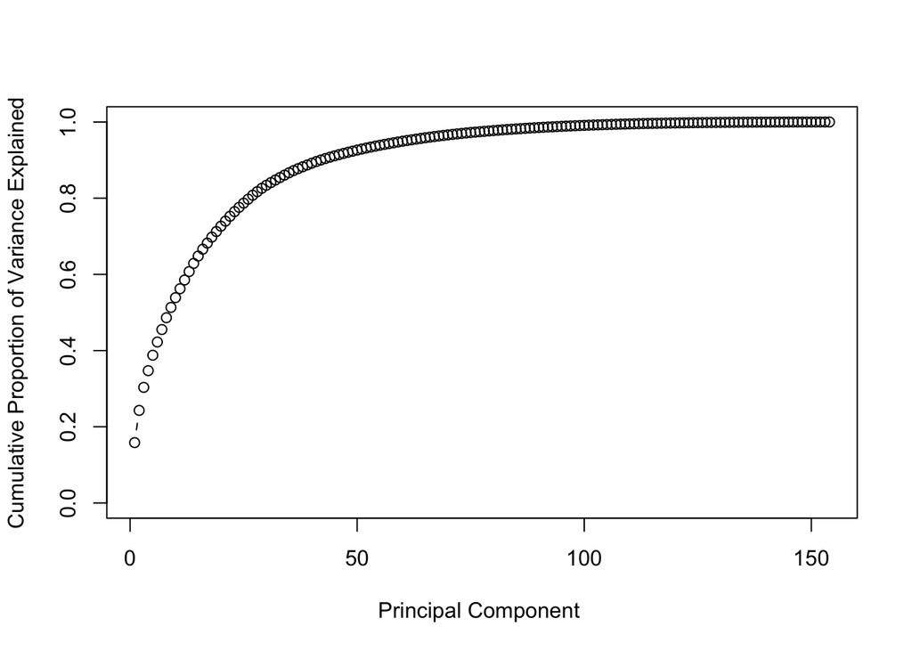

```r
plot(cumsum(pve), xlab="Principal Component ", ylab=" Cumulative Proportion of Variance Explained ", ylim=c(0,1), type='b')
```